This personalized report contains feedback in three parts. The **first part** contains feedback on your performance on the Desert Survival Task. The **second part** contains feedback from your participation in the group discussion. The **third part** contains a set of self-reflection questions to guide your interpretation of the results.  
You can watch a video of the meeting by clicking [**here**](https://www.dropbox.com/scl/fi/8x6tcpkm7db2861b7b76j/MBA25_17_video.mp4?rlkey=v98j9qxweidrb972rnbdopl7p&st=inj5qeyz&dl=0).

## Part One - Feedback on your performance on the Desert Survival Task

*Scores:* In the table below, you will find the experts’ rankings of the items, your own rankings, and the final rankings made by your group. To assess how you performed, we compare your rankings to the experts’ rankings and calculate the Spearman’s rank correlation coefficient, which is similar to a regular correlation coefficient. Using this methodology, the best possible score is +1 (which means that your answers would be exactly the same as the experts’) and the worst possible score is -1 (which means that your answers were exactly the opposite to the experts’). If answers are made randomly (e.g., by a monkey with darts), the expected coefficient is 0. A negative score therefore means that you did worse than random.  
You are also provided with a percentile ranking, which indicates how you compare to others who completed this task in the MBA Class. A percentile score, for instance, of 90 indicates that you did better than 90% of those who completed the task, while a percentile score of 10 indicates you did better than only 10% of others. Your group also receives a percentile, which indicates how your group’s performance compares to other groups.

|  | Experts’ Rankings | Your Rankings | Your Group’s Rankings |
| --- | --- | --- | --- |
| Cosmetic mirror | 1 | 5 | 9 |
| 1 topcoat per person | 2 | 4 | 4 |
| 1 litre of water per person | 3 | 1 | 1 |
| Flashlight (large size, bright, working) | 4 | 10 | 10 |
| Parachute (red and white) | 5 | 11 | 7 |
| Swiss Army Knife | 6 | 6 | 5 |
| Plastic raincoat (large size) | 7 | 13 | 13 |
| .45 calibre pistol(loaded) | 8 | 15 | 12 |
| A pair of sunglasses per person | 9 | 9 | 14 |
| Compress kit with gauze | 10 | 12 | 11 |
| Magnetic compass | 11 | 3 | 3 |
| Sectional air map of the area | 12 | 2 | 2 |
| Book, Edible Animals of the Desert | 13 | 7 | 6 |
| 2 litres of vodka | 14 | 14 | 15 |
| Bottle of salt tablets (1000 tablets) | 15 | 8 | 8 |
| Score |  | 0.22 | 0.19 |
| Percentile |  | 62 | 42 |

*Group Performance:* You estimated that your group would rank in the 80 percentile in the task. Actually, your group ranked in the 42 percentile.  
**Survey Information**  
*Contribution:* You and the other members of your group rated your contribution on the task (“This person contributed positively or negatively to the group’s final performance”, -3=Strongly negative, 3=Strongly positive). You rated your own contribution as 2 and received an average score of 2.5 from the rest of your group.  
*Fostered an enjoyable discussion:* You and the other members of your group rated the extent to which you fostered an enjoyable discussion (“This person contributed positively or negatively towards fostering an enjoyable discussion”, -3=Strongly negative, 3=Strongly positive). You rated your own contribution as 2 and received an average score of 2.5 from the rest of your group.  
*Influence:* The other members of your group rated your influence on the task (“This person influenced my perception of the optimum rankings for this task”, 1=Strongly Disagree, 7=Strongly Agree). You received an average score of 5.5 (out of 7) from the rest of your group.

## Part Two - Feedback on your participation

In this next section of the report, we will provide you with feedback on the impressions you made during the online meeting.  
*Speaking time:* How much did you and each of the other group-members speak during the task? Here is a breakdown of your estimates of how much each person spoke in the task, together with their actual speaking time statistics.

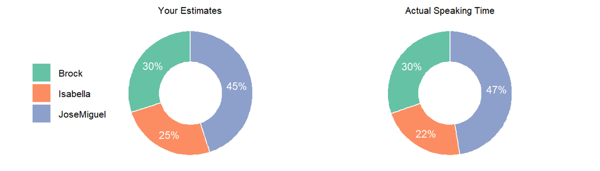

*Speaking time breakdown:* How did speaking time change over the course of the discussion? Were any people particularly active (or inactive) at specific times of the discussion? Here is a breakdown of each person’s speaking time during different 5-minute intervals starting from the beginning of the discussion.

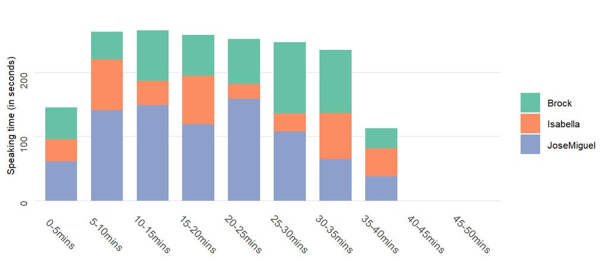

*Interruptions:* Who interrupted who in the discussion? Were there any people in the group that often interrupted others, or were often interrupted by others? Here is a breakdown of the number of times each person in the group interrupted others, and was interrupted.

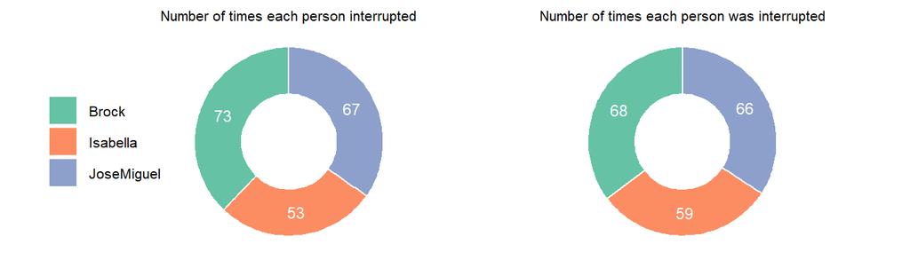

*Loudness:* Did some people speak louder than others? Did some people in the group vary how loudly they spoke over the discussion more than others? We measured the loudness of each person’s speech during the conversation and how it varied over the course of the discussion (which we measure using the standard deviation: the larger the standard deviation, the more loudness of speech varied in the conversation).

|  | Brock | Isabella | JoseMiguel | Group Average | Class Average |
| --- | --- | --- | --- | --- | --- |
| Average Loudness | 10.8 | 10.7 | 10.4 | 10.6 | 10 |
| Variation | 4 | 4 | 2.6 | 3.5 | 3.8 |
| Average Loudness - Percentile | 74 | 72 | 61 |  |  |
| Variation - Percentile | 63 | 61 | 4 |  |  |

*Sentiment analysis:* We measured the sentiment of your dialogue (i.e., whether the sentiment of each speaking occasion was positive, negative, neutral or mixed). We’ve included your scores, the average scores of the group and the average scores of everyone in the class. For this part of the analysis, we use a program from Amazon Web Services called “Amazon Comprehend”, which is a natural language processing (NLP) service that uses machine learning to find insights and relationships in text.

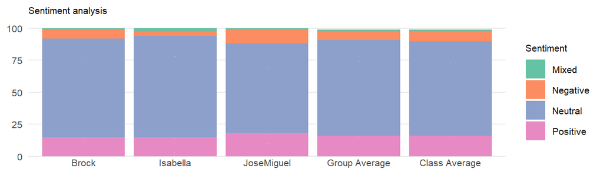

*Language content analysis:* We also looked at the content of your dialogue, using the Linguistic Inquiry and Word Count (LIWC), which is widely used in psychology academic research. LIWC scans text for words from its pre-defined dictionaries and returns scores based on how frequently words in these dictionaries appear in the text analysed. We have included your percentile score for Clout, compared to everyone in the class. Clout signals language of leadership and status (LIWC-22 Manual), and is derived by comparing and contrasting the use of the first-person plural (e.g., “We”) with use of the first-person singular (e.g., “I”). Research has shown that people with higher status use more first-person plural and fewer first-person singular pronouns, and this is linked with attentional focus on others, as opposed to the self (Kacewicz et al., 2014). Here, we show your Clout scores, compared to your other group-members.

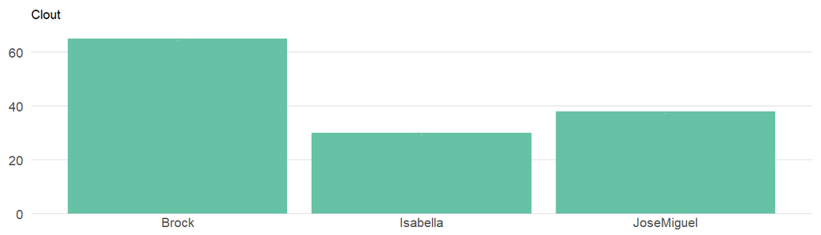